# AI Worker Burnout & Attrition — Classification Analysis

### Q5: LASSO/Ridge Feature Importance — What Drives Burnout? (CL3)

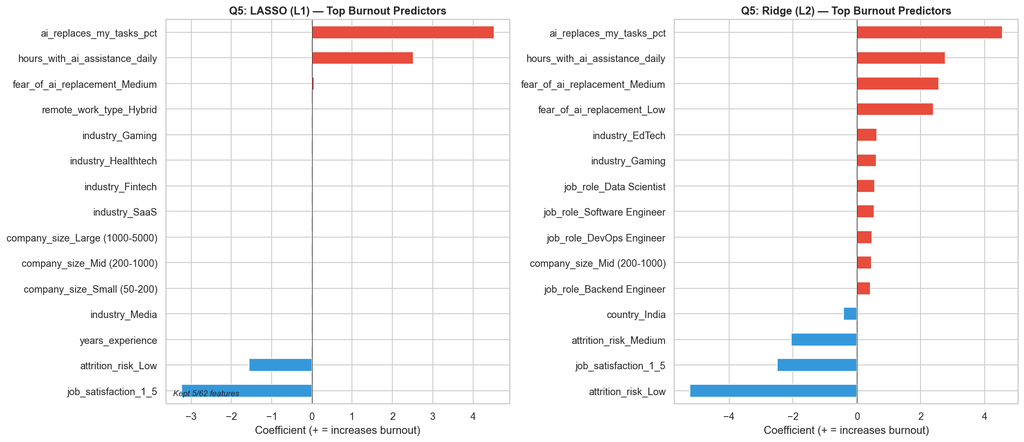

```python
# Compare LASSO vs Ridge coefficients for burnout prediction
fig, axes = plt.subplots(1, 2, figsize=(16, 7))

for ax, model_name in zip(axes, ['LASSO (L1)', 'Ridge (L2)']):
    model = q5_trained[model_name][0]
    coefs = pd.Series(model.coef_, index=X_q5.columns)
    top = coefs.abs().sort_values(ascending=False).head(15)
    top_vals = coefs[top.index].sort_values()
    colors = ['#e74c3c' if v > 0 else '#3498db' for v in top_vals.values]
    top_vals.plot(kind='barh', ax=ax, color=colors)
    ax.set_title(f'Q5: {model_name} — Top Burnout Predictors', fontweight='bold')
    ax.axvline(x=0, color='black', linewidth=0.5)
    ax.set_xlabel('Coefficient (+ = increases burnout)')
    if 'LASSO' in model_name:
        n_nonzero = (coefs != 0).sum()
        ax.text(0.02, 0.02, f'Kept {n_nonzero}/{len(coefs)} features',
                transform=ax.transAxes, fontsize=9, style='italic')

plt.tight_layout()
plt.show()
```

The LASSO (L1 regularization) coefficient plot appears sparse and uneven because of the inherent behavior of LASSO regression. Unlike Ridge regression, LASSO performs both regularization and feature selection by shrinking many coefficients exactly to zero. As a result, only a small subset of features retains non-zero coefficients, while the majority are eliminated.

In this analysis, LASSO retained only a few significant predictors out of a large feature set, causing the graph to display only a limited number of visible bars. This creates a “spiky” or irregular appearance, where a few features have relatively large coefficients while most others are zero and therefore not visible.

Additionally, LASSO tends to select one feature among a group of highly correlated variables and discard the others. This selective behavior can make the graph appear inconsistent or abrupt, even though it reflects the model’s effort to reduce redundancy and improve interpretability.

The magnitude and direction of the remaining coefficients indicate the strength and impact of each predictor on burnout. Positive coefficients suggest that an increase in the feature leads to higher burnout, while negative coefficients indicate a protective effect.

Overall, the unusual appearance of the LASSO plot is not an error but a meaningful outcome, demonstrating that burnout is driven by a small number of key variables rather than a large set of features.

Q5: Elastic Net/Ridge Feature Importance — What Drives Burnout? (CL3)

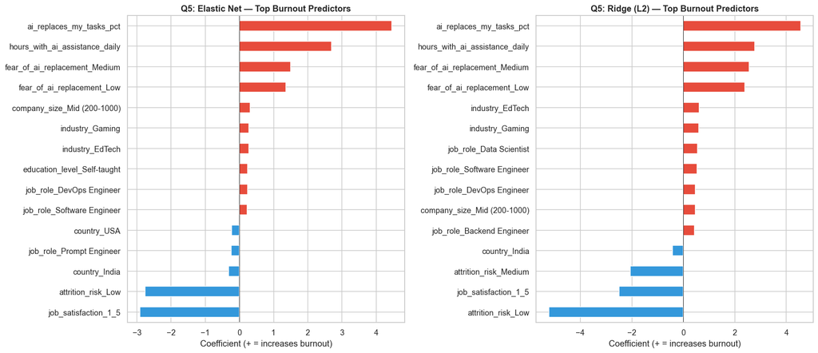

```python
# Compare Elastic Net vs Ridge coefficients for burnout prediction
fig, axes = plt.subplots(1, 2, figsize=(16, 7))

for ax, model_name in zip(axes, ['Elastic Net', 'Ridge (L2)']):
    model = q5_trained[model_name][0]
    coefs = pd.Series(model.coef_, index=X_q5.columns)
    top = coefs.abs().sort_values(ascending=False).head(15)
    top_vals = coefs[top.index].sort_values()
    colors = ['#e74c3c' if v > 0 else '#3498db' for v in top_vals.values]
    top_vals.plot(kind='barh', ax=ax, color=colors)
    ax.set_title(f'Q5: {model_name} — Top Burnout Predictors', fontweight='bold')
    ax.axvline(x=0, color='black', linewidth=0.5)
    ax.set_xlabel('Coefficient (+ = increases burnout)')
    if 'LASSO' in model_name:
        n_nonzero = (coefs != 0).sum()
        ax.text(0.02, 0.02, f'Kept {n_nonzero}/{len(coefs)} features',
                transform=ax.transAxes, fontsize=9, style='italic')

plt.tight_layout()
plt.show()
```

### Q5 Summary — What Drives Burnout Score?

**Best model:** Elastic Net — R²=0.6362, RMSE=6.8500, CV R²=0.6259  
**Runner-up:** Ridge (L2) (nearly identical: R²=0.634, RMSE=6.87, CV R²=0.624 ), Linear Regression (R²==0.634)  
**Tree models performed worse:** Random Forest (R²=0.588), Gradient Boost (R²=0.601) — suggesting the relationship is mostly **linear**

**Elastic Net confirms the same top factors** keeping all features. Compared to Ridge and Linear Regression, which performed almost identically, Elastic Net offers a key advantage by combining both L1 and L2 regularization. This allows it to handle multicollinearity effectively while also performing feature selection, resulting in a more balanced and interpretable model. Unlike LASSO, which aggressively removes features, Elastic Net retains important correlated variables while still reducing noise.

**Answer to Q5:** The model explains **63% of burnout score variance** (R²=0.634). The #1 burnout driver is **% of tasks replaced by AI** — the more AI takes over someone's work, the higher their burnout. **Daily AI-assisted hours** is the #2 factor. On the protective side, **job satisfaction** strongly reduces burnout. LASSO's extreme sparsity (5 features!) shows that burnout is driven by a **small set of AI-related factors**, not broad workplace characteristics. The remaining 37% unexplained variance likely comes from personal/psychological factors not in the dataset.